# Biceps Feedback

Bonnie Mohnsen

Background Using devices such as Jawbone Up, Nike FuelBand, and Fitbit it is now possible to collect a large amount of data about personal activity relatively inexpensively. These type of devices are part of the quantified self movement - a group of enthusiasts who take measurements about themselves regularly to improve their health, to find patterns in their behavior, or because they are tech geeks. One thing that people regularly do is quantify how much of a particular activity they do, but they rarely quantify how well they do it. In this project, your goal will be to use data from accelerometers on the belt, forearm, arm, and dumbell of 6 participants. They were asked to perform barbell lifts correctly and incorrectly in 5 different ways. More information is available from the website here: http://groupware.les.inf.puc-rio.br/har (see the section on the Weight Lifting Exercise Dataset).

Question

Can an algorithm be designed that can predict biceps curl errors in order to provide feedback to the performer?

Data

The training data for this project are available here:

https://d396qusza40orc.cloudfront.net/predmachlearn/pml-training.csv

The test data are available here:

https://d396qusza40orc.cloudfront.net/predmachlearn/pml-testing.csv

The data for this project came from this source: http://groupware.les.inf.puc-rio.br/har.

```
Classe A - exactly according to the specification
Classe B - throwing elbows to the front
Classe C - lifting the dumbbell only halfway
Classe D - lowering the dumbbell only halfway
Classe E - throwing the hips to the front
```

Overview

The goal is to predict the manner in which the exercise was performe. This is the “classe” variable (A, B, C, D, E) in the training set.

Code

```r
##Load libraries
library(caret)
```

```r
library(e1071)
library(ggplot2)
```

```r
##Read/input data
trainSet <- read.csv("pml-training.csv")
testSet <- read.csv("pml-testing.csv")
score_train <- trainSet$classe
```

```r
##Clean data for NA, substantial missing data, near zero variance, and first six columns
trainSet <- trainSet[, colSums(is.na(trainSet)) == 0]
testSet <- testSet[, colSums(is.na(testSet)) == 0]
nsv_train <- nearZeroVar(trainSet)
nsv_test <- nearZeroVar(testSet)
trainSet <- trainSet[-nsv_train]
testSet <- testSet[-nsv_test]
length_train <- length(trainSet)
length_test <- length(testSet)
trainSet <- trainSet[7:length_train]
testSet <- testSet[7:length_test]
```

```r
##Create partition
set.seed (1229)
inTrain <- createDataPartition(trainSet$classe, p=0.80, list=F)
trainSet <- trainSet[inTrain, ]
valSet <- trainSet[-inTrain, ]
```

```r
##Explore data
Summary(trainSet)
```

[output not shown]

```r
##Build SVM model and determine in and out of sample error (CM-confusion matrix)
model_svm <-svm(classe ~ ., data=trainSet)
predict_svm <- predict(model_svm, trainSet)
predict_CM_svm <- confusionMatrix(predict_svm,trainSet$classe)
predict_svm_val <- predict(model_svm, valSet)
predict_CM_svm_val <- confusionMatrix(predict_svm_val,valSet$classe)
```

```r
##Build random forest model (using 250 trees and 5 k-folds) and determine in and out of sample error
model_RF <- train(classe ~ ., data=trainSet, method="rf", trControl=trainControl(method="cv",number=5),prox=TRUE,allowParallel=TRUE, ntree=250)
predict_rf <- predict(model_RF, trainSet)
predict_CM_rf <- confusionMatrix(predict_rf, trainSet$classe)
predict_rf_val <- predict(model_RF, valSet)
predict_CM_rf_val <- confusionMatrix(predict_rf_val,valSet$classe)
```

```r
##Run model_RF on testSet
predict_rf_test <- predict(model_RF, testSet)
```

```r
##Prepare for submission
predict_rf_test <- as.vector(predict_rf_test)
n = length(predict_rf_test)
for(i in 1:n){
     filename = paste0("problem_id_",i,".txt")
     write.table(predict_rf_test[i],file=filename,quote=FALSE,row.names=FALSE,col.names=FALSE)
}
```

Conclusion I read in the training and testing sets, then I clean the data removing variables with a high number of NA, variables that were basically empty, and near zero variables. Additionally I reoved the first six column since they would have no baring on the model.

Appendix A Shows the accuracy of the model on the Validation Set

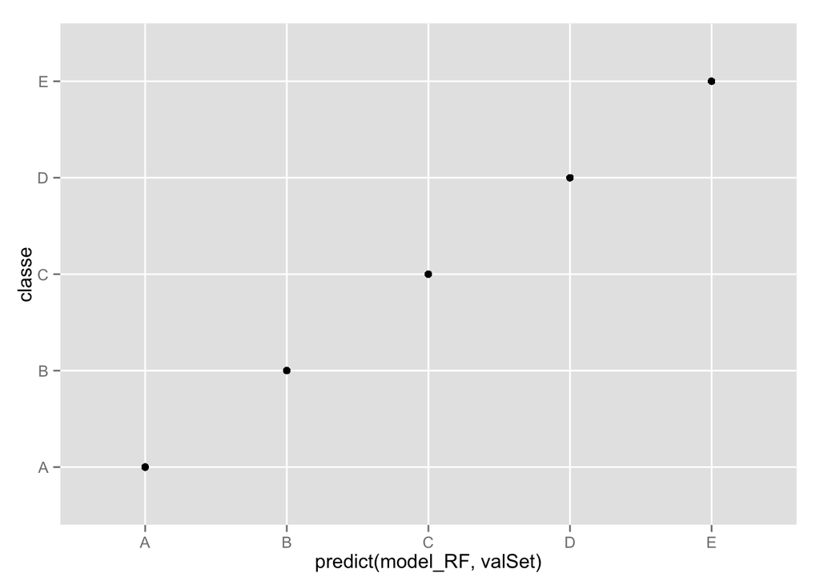

```r
plot1 <- qplot(predict(model_RF,valSet), classe, data=valSet)
plot1
```

Appendix B Shows the relative importance of variables

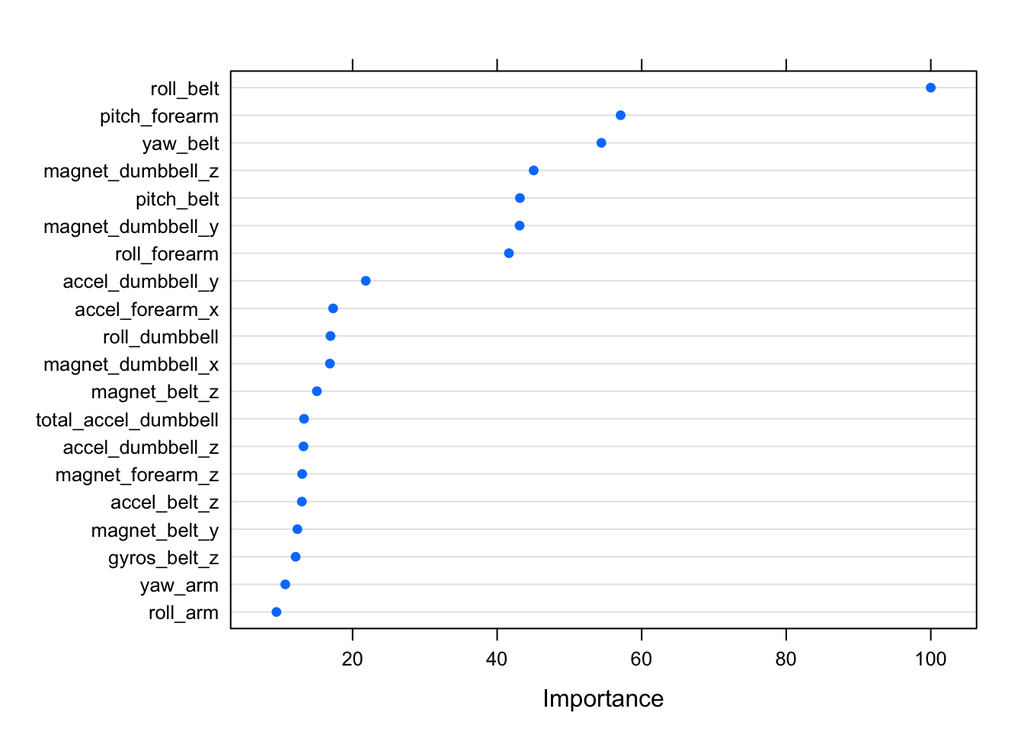

```r
plot2 <- dotPlot(varImp(model_RF))
plot2
```